# Risk Factor Analysis

## Outcome Variable

**Outcome Variable:** ever_co

## Predictor Variables

**Intervention Variable:** fhtcm

**Adjustment Set:**

- arm
- W_mage
- W_fage
- meducyrs
- feducyrs
- W_mhtcm
- W_mwtkg
- W_mbmi
- single
- delta_W_mage
- delta_W_fage
- delta_meducyrs
- delta_feducyrs
- delta_W_mhtcm
- delta_W_mwtkg
- delta_W_mbmi
- delta_single

## Stratifying Variables

The analysis was stratified on these variable(s):

- agecat
- studyid
- country

## Data Summary

| agecat | studyid | country | fhtcm | ever_co | n_cell | n |
| --- | --- | --- | --- | --- | --- | --- |
| 0-24 months | ki1000304b-SAS-CompFeed | INDIA | >=167 cm | 0 | 327 | 895 |
| 0-24 months | ki1000304b-SAS-CompFeed | INDIA | >=167 cm | 1 | 80 | 895 |
| 0-24 months | ki1000304b-SAS-CompFeed | INDIA | <162 cm | 0 | 162 | 895 |
| 0-24 months | ki1000304b-SAS-CompFeed | INDIA | <162 cm | 1 | 64 | 895 |
| 0-24 months | ki1000304b-SAS-CompFeed | INDIA | [162-167) cm | 0 | 196 | 895 |
| 0-24 months | ki1000304b-SAS-CompFeed | INDIA | [162-167) cm | 1 | 66 | 895 |
| 0-24 months | ki1000304b-SAS-FoodSuppl | INDIA | >=167 cm | 0 | 73 | 399 |
| 0-24 months | ki1000304b-SAS-FoodSuppl | INDIA | >=167 cm | 1 | 33 | 399 |
| 0-24 months | ki1000304b-SAS-FoodSuppl | INDIA | <162 cm | 0 | 84 | 399 |
| 0-24 months | ki1000304b-SAS-FoodSuppl | INDIA | <162 cm | 1 | 79 | 399 |
| 0-24 months | ki1000304b-SAS-FoodSuppl | INDIA | [162-167) cm | 0 | 91 | 399 |
| 0-24 months | ki1000304b-SAS-FoodSuppl | INDIA | [162-167) cm | 1 | 39 | 399 |
| 0-24 months | ki1101329-Keneba | GAMBIA | >=167 cm | 0 | 1061 | 1929 |
| 0-24 months | ki1101329-Keneba | GAMBIA | >=167 cm | 1 | 184 | 1929 |
| 0-24 months | ki1101329-Keneba | GAMBIA | <162 cm | 0 | 112 | 1929 |
| 0-24 months | ki1101329-Keneba | GAMBIA | <162 cm | 1 | 20 | 1929 |
| 0-24 months | ki1101329-Keneba | GAMBIA | [162-167) cm | 0 | 443 | 1929 |
| 0-24 months | ki1101329-Keneba | GAMBIA | [162-167) cm | 1 | 109 | 1929 |
| 0-24 months | ki1119695-PROBIT | BELARUS | >=167 cm | 0 | 11722 | 12537 |
| 0-24 months | ki1119695-PROBIT | BELARUS | >=167 cm | 1 | 22 | 12537 |
| 0-24 months | ki1119695-PROBIT | BELARUS | <162 cm | 0 | 168 | 12537 |
| 0-24 months | ki1119695-PROBIT | BELARUS | <162 cm | 1 | 0 | 12537 |
| 0-24 months | ki1119695-PROBIT | BELARUS | [162-167) cm | 0 | 624 | 12537 |
| 0-24 months | ki1119695-PROBIT | BELARUS | [162-167) cm | 1 | 1 | 12537 |
| 0-24 months | ki1135781-COHORTS | GUATEMALA | >=167 cm | 0 | 59 | 495 |
| 0-24 months | ki1135781-COHORTS | GUATEMALA | >=167 cm | 1 | 4 | 495 |
| 0-24 months | ki1135781-COHORTS | GUATEMALA | <162 cm | 0 | 244 | 495 |
| 0-24 months | ki1135781-COHORTS | GUATEMALA | <162 cm | 1 | 49 | 495 |
| 0-24 months | ki1135781-COHORTS | GUATEMALA | [162-167) cm | 0 | 119 | 495 |
| 0-24 months | ki1135781-COHORTS | GUATEMALA | [162-167) cm | 1 | 20 | 495 |

[output cut: 60 more lines]

The following strata were considered:

- agecat: 0-24 months, studyid: ki1000304b-SAS-CompFeed, country: INDIA
- agecat: 0-24 months, studyid: ki1000304b-SAS-FoodSuppl, country: INDIA
- agecat: 0-24 months, studyid: ki1101329-Keneba, country: GAMBIA
- agecat: 0-24 months, studyid: ki1119695-PROBIT, country: BELARUS
- agecat: 0-24 months, studyid: ki1135781-COHORTS, country: GUATEMALA
- agecat: 0-6 months, studyid: ki1000304b-SAS-CompFeed, country: INDIA
- agecat: 0-6 months, studyid: ki1000304b-SAS-FoodSuppl, country: INDIA
- agecat: 0-6 months, studyid: ki1101329-Keneba, country: GAMBIA
- agecat: 0-6 months, studyid: ki1119695-PROBIT, country: BELARUS
- agecat: 0-6 months, studyid: ki1135781-COHORTS, country: GUATEMALA
- agecat: 6-24 months, studyid: ki1000304b-SAS-CompFeed, country: INDIA
- agecat: 6-24 months, studyid: ki1000304b-SAS-FoodSuppl, country: INDIA
- agecat: 6-24 months, studyid: ki1101329-Keneba, country: GAMBIA
- agecat: 6-24 months, studyid: ki1119695-PROBIT, country: BELARUS
- agecat: 6-24 months, studyid: ki1135781-COHORTS, country: GUATEMALA

### Dropped Strata

Some strata were dropped due to rare outcomes:

- agecat: 0-24 months, studyid: ki1119695-PROBIT, country: BELARUS
- agecat: 0-24 months, studyid: ki1135781-COHORTS, country: GUATEMALA
- agecat: 0-6 months, studyid: ki1101329-Keneba, country: GAMBIA
- agecat: 0-6 months, studyid: ki1119695-PROBIT, country: BELARUS
- agecat: 0-6 months, studyid: ki1135781-COHORTS, country: GUATEMALA
- agecat: 6-24 months, studyid: ki1119695-PROBIT, country: BELARUS
- agecat: 6-24 months, studyid: ki1135781-COHORTS, country: GUATEMALA

## Methods Detail

We’re interested in the causal parameters $E[Y_a]$ for all values of $a \in \mathcal{A}$. These parameters represent the mean outcome if, possibly contrary to fact, we intervened to set all units to have $A=a$. Under the randomization and positivity assumptions, these are identified by the statistical parameters $\psi_a=E_W[E_{Y|A,W}(Y|A=a,W)]$. In addition, we’re interested in the mean of $Y$, $E[Y]$ under no intervention (the observed mean). We will estimate these parameters by using SuperLearner to fit the relevant likelihood factors – $E_{Y|A,W}(Y|A=a,W)$ and $p(A=a|W)$, and then updating our likelihood fit using a joint TMLE.

For unadjusted analyses ($W=\{\}$), initial likelihoods were estimated using Lrnr_glm to estimate the simple $E(Y|A)$ and Lrnr_mean to estimate $p(A)$. For adjusted analyses, a small library containing Lrnr_glmnet, Lrnr_xgboost, and Lrnr_mean was used.

Having estimated these parameters, we will then use the delta method to estimate relative risks and attributable risks relative to a prespecified baseline level of $A$.

# Results Detail

## Results Plots

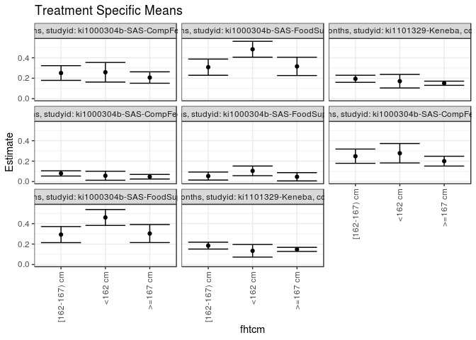

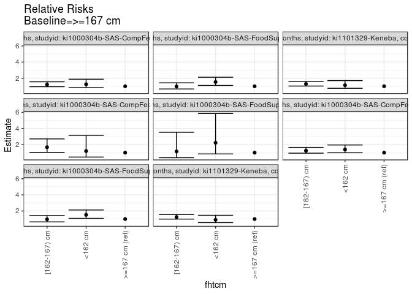

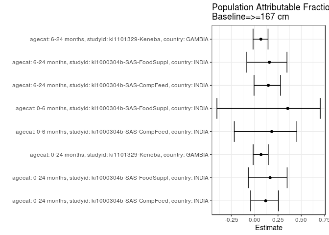

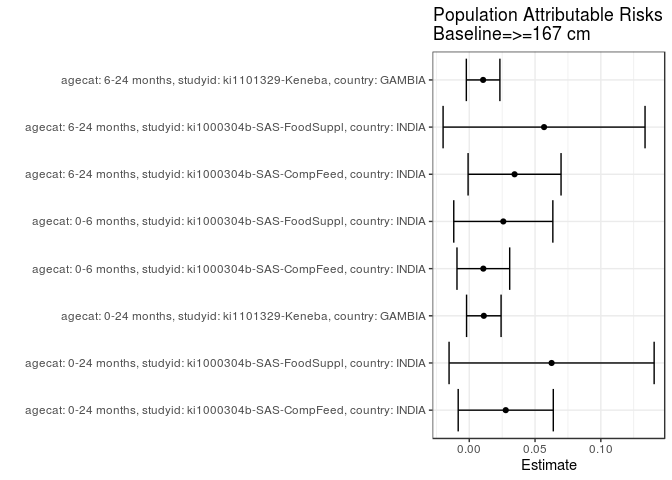

## Results Table

### Parameter: TSM

| agecat | studyid | country | intervention_level | baseline_level | estimate | ci_lower | ci_upper |
| --- | --- | --- | --- | --- | --- | --- | --- |
| 0-24 months | ki1000304b-SAS-CompFeed | INDIA | >=167 cm | NA | 0.2069030 | 0.1511954 | 0.2626106 |
| 0-24 months | ki1000304b-SAS-CompFeed | INDIA | <162 cm | NA | 0.2584315 | 0.1624642 | 0.3543988 |
| 0-24 months | ki1000304b-SAS-CompFeed | INDIA | [162-167) cm | NA | 0.2510504 | 0.1791226 | 0.3229781 |
| 0-24 months | ki1000304b-SAS-FoodSuppl | INDIA | >=167 cm | NA | 0.3158575 | 0.2264678 | 0.4052473 |
| 0-24 months | ki1000304b-SAS-FoodSuppl | INDIA | <162 cm | NA | 0.4834797 | 0.4058163 | 0.5611430 |
| 0-24 months | ki1000304b-SAS-FoodSuppl | INDIA | [162-167) cm | NA | 0.3082104 | 0.2290627 | 0.3873582 |
| 0-24 months | ki1101329-Keneba | GAMBIA | >=167 cm | NA | 0.1511856 | 0.1307487 | 0.1716226 |
| 0-24 months | ki1101329-Keneba | GAMBIA | <162 cm | NA | 0.1710760 | 0.1048697 | 0.2372823 |
| 0-24 months | ki1101329-Keneba | GAMBIA | [162-167) cm | NA | 0.1946417 | 0.1599587 | 0.2293247 |
| 0-6 months | ki1000304b-SAS-CompFeed | INDIA | >=167 cm | NA | 0.0478564 | 0.0253310 | 0.0703818 |
| 0-6 months | ki1000304b-SAS-CompFeed | INDIA | <162 cm | NA | 0.0574001 | 0.0134317 | 0.1013686 |
| 0-6 months | ki1000304b-SAS-CompFeed | INDIA | [162-167) cm | NA | 0.0802750 | 0.0546543 | 0.1058957 |
| 0-6 months | ki1000304b-SAS-FoodSuppl | INDIA | >=167 cm | NA | 0.0471698 | 0.0067604 | 0.0875792 |
| 0-6 months | ki1000304b-SAS-FoodSuppl | INDIA | <162 cm | NA | 0.1049383 | 0.0576850 | 0.1521915 |
| 0-6 months | ki1000304b-SAS-FoodSuppl | INDIA | [162-167) cm | NA | 0.0542636 | 0.0151218 | 0.0934053 |
| 6-24 months | ki1000304b-SAS-CompFeed | INDIA | >=167 cm | NA | 0.2000068 | 0.1519523 | 0.2480612 |
| 6-24 months | ki1000304b-SAS-CompFeed | INDIA | <162 cm | NA | 0.2775220 | 0.1826018 | 0.3724422 |
| 6-24 months | ki1000304b-SAS-CompFeed | INDIA | [162-167) cm | NA | 0.2484032 | 0.1787154 | 0.3180909 |
| 6-24 months | ki1000304b-SAS-FoodSuppl | INDIA | >=167 cm | NA | 0.3028359 | 0.2147769 | 0.3908948 |
| 6-24 months | ki1000304b-SAS-FoodSuppl | INDIA | <162 cm | NA | 0.4600361 | 0.3824589 | 0.5376133 |
| 6-24 months | ki1000304b-SAS-FoodSuppl | INDIA | [162-167) cm | NA | 0.2925710 | 0.2139789 | 0.3711631 |
| 6-24 months | ki1101329-Keneba | GAMBIA | >=167 cm | NA | 0.1478410 | 0.1278465 | 0.1678355 |
| 6-24 months | ki1101329-Keneba | GAMBIA | <162 cm | NA | 0.1341234 | 0.0724584 | 0.1957884 |
| 6-24 months | ki1101329-Keneba | GAMBIA | [162-167) cm | NA | 0.1846686 | 0.1511711 | 0.2181662 |

### Parameter: E(Y)

| agecat | studyid | country | intervention_level | baseline_level | estimate | ci_lower | ci_upper |
| --- | --- | --- | --- | --- | --- | --- | --- |
| 0-24 months | ki1000304b-SAS-CompFeed | INDIA | NA | NA | 0.2346369 | 0.1798928 | 0.2893809 |
| 0-24 months | ki1000304b-SAS-FoodSuppl | INDIA | NA | NA | 0.3784461 | 0.3307978 | 0.4260945 |
| 0-24 months | ki1101329-Keneba | GAMBIA | NA | NA | 0.1622602 | 0.1458031 | 0.1787174 |
| 0-6 months | ki1000304b-SAS-CompFeed | INDIA | NA | NA | 0.0585586 | 0.0394255 | 0.0776916 |
| 0-6 months | ki1000304b-SAS-FoodSuppl | INDIA | NA | NA | 0.0730479 | 0.0474188 | 0.0986769 |
| 6-24 months | ki1000304b-SAS-CompFeed | INDIA | NA | NA | 0.2344498 | 0.1848813 | 0.2840182 |
| 6-24 months | ki1000304b-SAS-FoodSuppl | INDIA | NA | NA | 0.3596939 | 0.3121253 | 0.4072624 |
| 6-24 months | ki1101329-Keneba | GAMBIA | NA | NA | 0.1583784 | 0.1417371 | 0.1750196 |

### Parameter: RR

| agecat | studyid | country | intervention_level | baseline_level | estimate | ci_lower | ci_upper |
| --- | --- | --- | --- | --- | --- | --- | --- |
| 0-24 months | ki1000304b-SAS-CompFeed | INDIA | >=167 cm | >=167 cm | 1.0000000 | 1.0000000 | 1.000000 |
| 0-24 months | ki1000304b-SAS-CompFeed | INDIA | <162 cm | >=167 cm | 1.2490467 | 0.8304279 | 1.878691 |
| 0-24 months | ki1000304b-SAS-CompFeed | INDIA | [162-167) cm | >=167 cm | 1.2133724 | 0.9458231 | 1.556605 |
| 0-24 months | ki1000304b-SAS-FoodSuppl | INDIA | >=167 cm | >=167 cm | 1.0000000 | 1.0000000 | 1.000000 |
| 0-24 months | ki1000304b-SAS-FoodSuppl | INDIA | <162 cm | >=167 cm | 1.5306890 | 1.1042227 | 2.121863 |
| 0-24 months | ki1000304b-SAS-FoodSuppl | INDIA | [162-167) cm | >=167 cm | 0.9757894 | 0.6662955 | 1.429043 |
| 0-24 months | ki1101329-Keneba | GAMBIA | >=167 cm | >=167 cm | 1.0000000 | 1.0000000 | 1.000000 |
| 0-24 months | ki1101329-Keneba | GAMBIA | <162 cm | >=167 cm | 1.1315623 | 0.7517050 | 1.703372 |
| 0-24 months | ki1101329-Keneba | GAMBIA | [162-167) cm | >=167 cm | 1.2874351 | 1.0303954 | 1.608595 |
| 0-6 months | ki1000304b-SAS-CompFeed | INDIA | >=167 cm | >=167 cm | 1.0000000 | 1.0000000 | 1.000000 |
| 0-6 months | ki1000304b-SAS-CompFeed | INDIA | <162 cm | >=167 cm | 1.1994238 | 0.4570734 | 3.147454 |
| 0-6 months | ki1000304b-SAS-CompFeed | INDIA | [162-167) cm | >=167 cm | 1.6774130 | 1.0396655 | 2.706365 |
| 0-6 months | ki1000304b-SAS-FoodSuppl | INDIA | >=167 cm | >=167 cm | 1.0000000 | 1.0000000 | 1.000000 |
| 0-6 months | ki1000304b-SAS-FoodSuppl | INDIA | <162 cm | >=167 cm | 2.2246913 | 0.8451872 | 5.855805 |
| 0-6 months | ki1000304b-SAS-FoodSuppl | INDIA | [162-167) cm | >=167 cm | 1.1503876 | 0.3753798 | 3.525474 |
| 6-24 months | ki1000304b-SAS-CompFeed | INDIA | >=167 cm | >=167 cm | 1.0000000 | 1.0000000 | 1.000000 |
| 6-24 months | ki1000304b-SAS-CompFeed | INDIA | <162 cm | >=167 cm | 1.3875631 | 0.9850721 | 1.954508 |
| 6-24 months | ki1000304b-SAS-CompFeed | INDIA | [162-167) cm | >=167 cm | 1.2419740 | 0.9335939 | 1.652217 |
| 6-24 months | ki1000304b-SAS-FoodSuppl | INDIA | >=167 cm | >=167 cm | 1.0000000 | 1.0000000 | 1.000000 |
| 6-24 months | ki1000304b-SAS-FoodSuppl | INDIA | <162 cm | >=167 cm | 1.5190939 | 1.0862839 | 2.124349 |
| 6-24 months | ki1000304b-SAS-FoodSuppl | INDIA | [162-167) cm | >=167 cm | 0.9661043 | 0.6502653 | 1.435349 |
| 6-24 months | ki1101329-Keneba | GAMBIA | >=167 cm | >=167 cm | 1.0000000 | 1.0000000 | 1.000000 |
| 6-24 months | ki1101329-Keneba | GAMBIA | <162 cm | >=167 cm | 0.9072140 | 0.5618444 | 1.464885 |
| 6-24 months | ki1101329-Keneba | GAMBIA | [162-167) cm | >=167 cm | 1.2491033 | 0.9964930 | 1.565750 |

### Parameter: PAR

| agecat | studyid | country | intervention_level | baseline_level | estimate | ci_lower | ci_upper |
| --- | --- | --- | --- | --- | --- | --- | --- |
| 0-24 months | ki1000304b-SAS-CompFeed | INDIA | >=167 cm | NA | 0.0277339 | -0.0084035 | 0.0638712 |
| 0-24 months | ki1000304b-SAS-FoodSuppl | INDIA | >=167 cm | NA | 0.0625886 | -0.0153411 | 0.1405182 |
| 0-24 months | ki1101329-Keneba | GAMBIA | >=167 cm | NA | 0.0110746 | -0.0020414 | 0.0241906 |
| 0-6 months | ki1000304b-SAS-CompFeed | INDIA | >=167 cm | NA | 0.0107021 | -0.0093260 | 0.0307303 |
| 0-6 months | ki1000304b-SAS-FoodSuppl | INDIA | >=167 cm | NA | 0.0258780 | -0.0117754 | 0.0635315 |
| 6-24 months | ki1000304b-SAS-CompFeed | INDIA | >=167 cm | NA | 0.0344430 | -0.0008826 | 0.0697686 |
| 6-24 months | ki1000304b-SAS-FoodSuppl | INDIA | >=167 cm | NA | 0.0568580 | -0.0198865 | 0.1336025 |
| 6-24 months | ki1101329-Keneba | GAMBIA | >=167 cm | NA | 0.0105374 | -0.0022145 | 0.0232893 |

### Parameter: PAF

| agecat | studyid | country | intervention_level | baseline_level | estimate | ci_lower | ci_upper |
| --- | --- | --- | --- | --- | --- | --- | --- |
| 0-24 months | ki1000304b-SAS-CompFeed | INDIA | >=167 cm | NA | 0.1181991 | -0.0429524 | 0.2544503 |
| 0-24 months | ki1000304b-SAS-FoodSuppl | INDIA | >=167 cm | NA | 0.1653831 | -0.0682455 | 0.3479164 |
| 0-24 months | ki1101329-Keneba | GAMBIA | >=167 cm | NA | 0.0682520 | -0.0160734 | 0.1455792 |
| 0-6 months | ki1000304b-SAS-CompFeed | INDIA | >=167 cm | NA | 0.1827597 | -0.2188026 | 0.4520181 |
| 0-6 months | ki1000304b-SAS-FoodSuppl | INDIA | >=167 cm | NA | 0.3542615 | -0.4046217 | 0.7031385 |
| 6-24 months | ki1000304b-SAS-CompFeed | INDIA | >=167 cm | NA | 0.1469100 | -0.0066469 | 0.2770429 |
| 6-24 months | ki1000304b-SAS-FoodSuppl | INDIA | >=167 cm | NA | 0.1580733 | -0.0846091 | 0.3464553 |
| 6-24 months | ki1101329-Keneba | GAMBIA | >=167 cm | NA | 0.0665332 | -0.0171727 | 0.1433507 |